# 2021-03-25_Workbook_5

### Brief report of the results Question 3

4. Using the nz dataset, write a regression model for height as predicted by male_id

```r
#filtering by wave
nz_4 <- nz %>%
  select (HLTH.Height, Wave, male_id) %>% #selecting only variables we are interested in.
  filter(Wave == "2019") #filtering to only 2019 wave.

#table
model_2 <- lm(HLTH.Height ~ male_id, data = nz_4)
sjPlot::tab_model(model_2) # creating a table of height vs male_id.
```

|  | HLTH.Height |  |  |
| --- | --- | --- | --- |
| Predictors | Estimates | CI | p |
| (Intercept) | 1.78 | 1.77 – 1.78 | **<0.001** |
| male_id [Not_Male] | -0.13 | -0.13 – -0.12 | **<0.001** |
| Observations | 2034 |  |  |
| R<sup>2</sup> / R<sup>2</sup> adjusted | 0.384 / 0.383 |  |  |

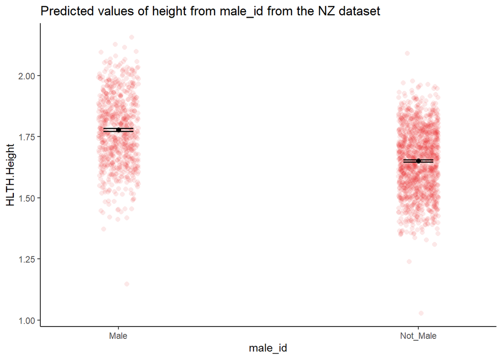

```r
# graph
Graph_4 <- ggeffects::ggpredict(model_2, terms = "male_id")
# we use a predict graph because it helps to clarify data further
fourplot <- plot(Graph_4, add.data = TRUE, dot.alpha = .1, jitter = TRUE) +   theme_classic()
fourplot + labs(title = "Predicted values of height from male_id from the NZ dataset")
```

### Brief report of the results Question 4.

The above table shows that the average height is predicted by the male_id variable. (CI = 1.77 - 1.78, p = <0.001). The graph depicts that on average and statistically significantly, those that identified as male in the dataset are taller.

5. Predict the heights of daughter of women in the nz dataset.

```r
# looking at the labels of the pearson data.
head(md_df)
```

```
##   daughter_height mother_height mother_height_c
## 1            52.5          59.5       -2.998733
## 2            52.5          59.5       -2.998733
## 3            53.5          59.5       -2.998733
## 4            53.5          59.5       -2.998733
## 5            55.5          59.5       -2.998733
## 6            55.5          59.5       -2.998733
```

```r
# start with the linear model
lmdat2 <- lm(daughter_height ~ mother_height, data = md_df)
sjPlot::tab_model(lmdat2)
```

|  | daughter_height |  |  |
| --- | --- | --- | --- |
| Predictors | Estimates | CI | p |
| (Intercept) | 29.80 | 28.25 – 31.35 | **<0.001** |
| mother_height | 0.54 | 0.52 – 0.57 | **<0.001** |
| Observations | 5524 |  |  |
| R<sup>2</sup> / R<sup>2</sup> adjusted | 0.252 / 0.252 |  |  |

```r
#then we want to make a new dataframe and expand its limits.

nz_6 <- nz %>%
  select (HLTH.Height, Wave, Male) %>%
  filter(Wave == "2019", Male == "Not_Male")

summary(nz_6) # this allows a summary of min/max etc.
```

```
##   HLTH.Height      Wave            Male
##  Min.   :1.200   2018:   0   Male    :   0
##  1st Qu.:1.600   2019:1305   Not_Male:1305
##  Median :1.650
##  Mean   :1.651
##  3rd Qu.:1.700
##  Max.   :1.940
##  NA's   :17
```

```r
#find that min height is 1.2m, max 1.94m
# but the pearson dataset is in inches not meters!!
# from google the NZ min is 47.2inches and max is 76.38inches.

# make a new dataframe and expand its limits to the NZ's min and max
datafr1 <- expand.grid(mother_height = c(47.2:74.8))
# this is the X variable

# use the `predict` function to create a new response
predict1 <- predict(lmdat2, type = "response", interval = "confidence", newdata = datafr1)
# this creates the Y variable

# have a look at the object
dplyr::glimpse(predict1)
```

```
##  num [1:28, 1:3] 55.5 56.1 56.6 57.2 57.7 ...
##  - attr(*, "dimnames")=List of 2
##   ..$ : chr [1:28] "1" "2" "3" "4" ...
##   ..$ : chr [1:3] "fit" "lwr" "upr"
```

```r
#Put X and Y variables together and report the findings
library(ggeffects)
together <- ggeffects::ggpredict(lmdat2, terms = "mother_height")
together # note the X is the mothers heights
```

```
## # Predicted values of daughter_height
## # x = mother_height
##
##     x | Predicted |         95% CI
## ----------------------------------
## 52.50 |     58.41 | [58.15, 58.66]
## 54.50 |     59.50 | [59.29, 59.70]
## 57.50 |     61.13 | [60.99, 61.27]
## 59.50 |     62.22 | [62.13, 62.32]
## 61.50 |     63.31 | [63.25, 63.38]
## 63.50 |     64.40 | [64.34, 64.47]
## 65.50 |     65.49 | [65.40, 65.59]
## 70.50 |     68.22 | [68.01, 68.42]
```

6. BONUS - diff in heights in women in 2019 nz compared with women in 1903 dataset. clarify the inference.

```r
# below is an attempt. Realised would need to transform one of the datasets to make them both the same measurement (ie ones in inches, ones in metres).

nz_60 <- nz %>%
  filter(Wave == "2019", Male == "Not_Male") %>% #filtering only relevant columns
  select(HLTH.Height) %>% # selecting only the heights
  rename(Height = HLTH.Height) #renaming height columns

head(nz_60) #checking the above has worked
```

```
## # A tibble: 6 x 1
##   Height
##    <dbl>
## 1   1.58
## 2   1.6
## 3   1.69
## 4   1.65
## 5   1.68
## 6   1.75
```

```r
md_60 <- md_df %>%
  select(mother_height) %>% #selecting only women heights
  rename(Height = mother_height) #renaming so that both df's match

head(md_60) #checking the above worked
```

```
##   Height
## 1   59.5
## 2   59.5
## 3   59.5
## 4   59.5
## 5   59.5
## 6   59.5
```

```r
library(compareDF) #will allow comparison of two datasets
ctable_heights = compare_df(nz_60, md_60, c("Height")) #comparing both new df's with newly created columns "Height"
```

```
## Creating comparison table...
```

```r
ctable_heights$comparison_df #printing the outcome
```

```
##    Height chng_type
## 1   1.200         +
## 2   1.250         +
## 3   1.400         +
## 4   1.477         +
## 5   1.525         +
## 6   1.545         +
## 7   1.626         +
## 8   1.702         +
## 9   1.737         +
## 10  1.810         +
## 11  1.840         +
## 12  1.870         +
## 13  1.880         +
## 14  1.940         +
```

```r
print(ctable_heights) # peinting the full outcome
```

```
## $comparison_df
##    Height chng_type
## 1   1.200         +
## 2   1.250         +
## 3   1.400         +
## 4   1.477         +
## 5   1.525         +
## 6   1.545         +
## 7   1.626         +
## 8   1.702         +
## 9   1.737         +
## 10  1.810         +
## 11  1.840         +
## 12  1.870         +
## 13  1.880         +
```

[output cut: 79 more lines]